# Recording shortest paths in Floyd-Warshall

Charles Zheng

06/20/2015

# Setup

Let $A$ be an $n \times n$ adjacency matrix of a weighted directed graph (missing edges = $\infty$.)

The Floyd-Warshall algorithm can be used to find the shortest path distances while also recording the shortest paths.

Let $S$ be the matrix of shortest path distances. Initialize $S^{(0)} = A$. Let $P$ be an $n \times n$ array of vectors containing the sequences of nodes constituting the shortest paths (containing both the start and end).

For iteration $k = 1,...,n$.

- For $i, j \in [n]^2$:
- If $S_{ij} > S_{ik} + S_{kj}$, then update $S_{ij} \leftarrow S_{ik} + S_{kj}$. Also update $P_{ij} \leftarrow P_{ik} + P_{kj}$ where `+` denotes list concatenation.
- EndFor

Code for Floyd-Warshall:

```r
library(matlab, quietly = TRUE, warn.conflicts = FALSE)
floyd_warshall <- function(A) {
  n <- dim(A)[1]
  S <- A
  P <- cell(n)
  rownames(P) <- rownames(A); colnames(P) <- colnames(A)
  # intialize P
  #  P[i, j] is a vector v where v[i] indicates position of node and
  #  names(P)[i] indicates the node ID
  for (i in 1:n) {
    for (j in 1:n) {
      P[[i, j]] <- c(0, 1)
      names(P[[i, j]]) <- rownames(A)[c(i, j)]
    }
  }
  # Floyd-Warshall algorithm
  for (k in 1:n) {
    for (i in 1:n) {
      for (j in 1:n) {
        if (S[i, j] > S[i, k] + S[k, j]) {
          S[i, j] <- S[i, k] + S[k, j]
          v1 <- P[[i, k]]
          v2 <- P[[k, j]] + max(v1)
          P[[i, j]] <- c(v1, v2[-1])
        }
      }
    }
  }
  list(S = S, P = P)
}
```

In the following simulation, we generate a random graph and label the nodes by `A`, `B`, `C`,… `Z`.

### Graph generation

```r
library(pracma, quietly = TRUE, warn.conflicts = FALSE)
n <- 50
# random log-normal weights
A <- exp(randn(n))
# delete some edges randomly
A[rand(n) > 3/n] <- Inf
# set diagonals to 0
diag(A) <- 0
SLETTERS <- c(LETTERS, paste0(rep(LETTERS, each = 26), rep(LETTERS, 26)))
rownames(A) <- SLETTERS[1:n]
colnames(A) <- SLETTERS[1:n]
```

Apply the algorithm

```r
res <- floyd_warshall(A); S <- res$S; P <- res$P
# the path lengths
L <- apply(P, c(1, 2), function(v) max(v[[1]]))
table(L)
```

```
## L
##   1   2   3   4   5   6   7   8   9  10
## 516 270 407 420 381 268 159  65  12   2
```

Find a particular path (of large length) and check it

```r
i <- row(L)[L == max(L)][1]
j <- col(L)[L == max(L)][1]
L[i, j]
```

```
## [1] 10
```

```r
P[[i, j]]
```

```
##  R AA  L AJ  D  G AG  V  U  C  Q
##  0  1  2  3  4  5  6  7  8  9 10
```

Is this indeed the shortest path?

```r
nodes <- names(P[[i, j]])
(edges <- cbind(nodes[-length(nodes)], nodes[-1]))
```

```
##       [,1] [,2]
##  [1,] "R"  "AA"
##  [2,] "AA" "L"
##  [3,] "L"  "AJ"
##  [4,] "AJ" "D"
##  [5,] "D"  "G"
##  [6,] "G"  "AG"
##  [7,] "AG" "V"
##  [8,] "V"  "U"
##  [9,] "U"  "C"
## [10,] "C"  "Q"
```

```r
interdists <- A[edges]
S[i, j]
```

```
## [1] 5.376941
```

```r
sum(interdists)
```

```
## [1] 5.376941
```

# Problem

To reduce the storage requirement, we can store partial path information in each entry $P_{ij}$. After the completion of the FW algorithm, any complete path can be recovered by iteratively querying the elements of $P_{ij}$.

Consider fixing a number $M$ which limits the number of node that can be stored per path (per pair of vertices.) How can we choose which nodes to store (each time a path is upated in Floyd-Warshall) so that we can efficiently query the path later?

Note, $M$ does not include the start and end nodes, which we are storing for convenience of exposition. So in our implementation we store $M + 2$ nodes.

# Random selection approach

Here is one approach to the problem. Whenever the number of nodes in the path exceeds $M$, uniformly downsample the nodes selected. As a convention, always keep the end node. There is no need to keep the end node, but in this example it keeps track of the path length, which is convenient.

Downsampling subroutine (inside the inner loop of Floyd-Warshall):

- If $S_{ij} > S_{ik} + S_{kj}$, then:
- $S_{ij} \leftarrow S_{ik} + S_{kj}$
- $P_{ij} \leftarrow P_{ik} + P_{kj}$
- If $P_{ij}$ contains more than $M$ intermediate nodes:
- Choose $M$ of intermediate nodes at random (without replacement) and store only those nodes in $P_{ij}$.
- EndIf
- EndIf

```r
fw_downsample <- function(A, M) {
  n <- dim(A)[1]
  S <- A
  P <- cell(n)
  rownames(P) <- rownames(A); colnames(P) <- colnames(A)
  for (i in 1:n) {
    for (j in 1:n) {
      P[[i, j]] <- c(0, 1)
      names(P[[i, j]]) <- rownames(A)[c(i, j)]
    }
  }
  for (k in 1:n) {
    for (i in 1:n) {
      for (j in 1:n) {
        if (S[i, j] > S[i, k] + S[k, j]) {
          S[i, j] <- S[i, k] + S[k, j]
          v1 <- P[[i, k]]
          v2 <- P[[k, j]] + max(v1)
          v <- c(v1, v2[-1])
          # downsampling step
          if (length(v) > M + 2) {
            vmid <- v[2:(length(v) - 1)]
            inds <- sort(sample(length(vmid), M, replace = FALSE))
            v <- c(v[1], vmid[inds], v[length(v)])
          }
          P[[i, j]] <- v
        }
      }
    }
  }
  list(S = S, P = P)
}
```

Code for recovering path $P_{i, j}$.

```r
diff1 <- function(v) v[-length(v)] - v[-1]
query_path <- function(P, i, j) {
  iter_count <- 1
  nodes <- P[[i, j]]
  while (max(-diff1(nodes)) > 1) {
    iter_count <- iter_count + 1
    gaps <- which(-diff1(nodes) > 1)
    edges <- cbind(names(nodes)[-length(nodes)], names(nodes)[-1])[gaps, , drop = FALSE]
    paths <- P[edges, drop = FALSE]
    # insert missing nodes
    for (no in 1:length(gaps)) {
      edge <- edges[no, ]
      path <- paths[[no]]
      ind <- which(names(nodes) == edge[1])
      pos <- nodes[ind]
      pre_edge <- nodes[1:ind]
      post_edge <- nodes[(ind + 1):length(nodes)]
      # insert path between pre-edge and post_edge (minus duplicated end node)
      nodes <- c(pre_edge, pos + path[-1], post_edge[-1])
    }
  }
  list(path = nodes, iter_count = iter_count)
}
```

Downsample with $M = 3$

```r
res_d <- fw_downsample(A, 3)
# the full path
P[[i, j]]
```

```
##  R AA  L AJ  D  G AG  V  U  C  Q
##  0  1  2  3  4  5  6  7  8  9 10
```

```r
# the stored path
res_d$P[[i, j]]
```

```
##  R AA  L  D  Q
##  0  1  2  4 10
```

Recover the full path

```r
rec <- query_path(res_d$P, i, j)
# the recovered full path
rec$path
```

```
##  R AA  L AJ  D  G AG  V  U  C  Q
##  0  1  2  3  4  5  6  7  8  9 10
```

```r
# number of iterations
rec$iter_count
```

```
## [1] 3
```

While random selection has decent performance for random graphs or graphs with pre-shuffled vertices, it can be shown to have worst-case performance of taking $O(n/M)$ iterations.

# Greedy merging approach

We present a deterministic scheme that has better worst-case performance. It depends on the following result.

## Subsequence compression theorem

Suppose we have a sequence of integers $x_0 = 0 \leq x_1 \leq x_2 \leq ... \leq x_{L-1} \leq x_L = N$ satisfying $\max_{j=0}^{L-1} (x_{j+1} - x_j) \leq \epsilon N$ Now consider all subsequences of the form $x_{i_0} = 0 \leq x_{i_1} \leq ... \leq x_{i_K} \leq x_{i_K} = x_L = N$ such that $\max_{j=0}^{K-1} (x_{i_{j+1}} - x_{i_j}) \leq \epsilon N$ The key result is that there exists such a subsequence with length $L \leq 2\left(\frac{1}{\epsilon + (1/N)} - \frac{1}{1 + \epsilon N}\right) + 1 \approx \frac{2}{\epsilon}$ (where the approximation is for large $N$) and furthermore, it can be found using a greedy algorithm.

The greedy algorithm is as follows (code):

```r
epsilon_check <- function(x, epsilon) {
  L <- length(x)
  N <- x[L]
  val1 <- x[1]==0
  val2 <- max(-diff1(x)) <= epsilon * N
  val1 && val2
}

epsilon_compress <- function(x, epsilon) {
  L <- length(x)
  N <- x[L]
  stopifnot(epsilon_check(x, epsilon))
  filt <- rep(FALSE, L)  # indices of subsequence
  blockend <- 1
  flag <- TRUE
  while (blockend < L) {
    blockstart <- blockend
    filt[blockstart] <- TRUE
    blockend <- max(which(x - x[blockstart] < epsilon * N))
  }
  filt[blockend] <- TRUE
  stopifnot(-diff1(x[filt]) <= epsilon * N)
  x[filt]
}
```

In fact, any greedy algorithm which repeatedly merges gaps of total distance less than $\epsilon N$ until none remain (in any order) will work.

Define $\epsilon(M) \approx \frac{2}{M}$ to be the constant as a function of $M$ by $\epsilon(M) = \text{argmax}_\epsilon \text{such that }\max_{N=M}^\infty 2\left(\frac{1}{\epsilon + (1/N)} - \frac{1}{1 + \epsilon N}\right) + 1 < M$ It turns out the maximum over $N$ is always attained in the infinite limit. Therefore we have $\epsilon(M) = \min(1, \frac{2}{M - 1})$

We compute an approximation of $\epsilon(M)$

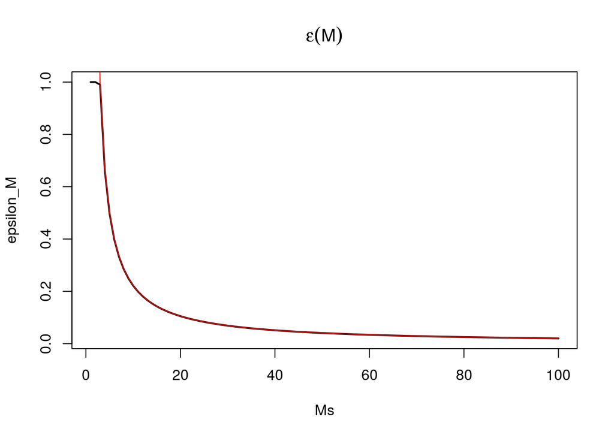

```r
ns <- 1:1000
eps <- 100/(100:10000)
epsmat <- repmat(t(t(eps)), 1, length(ns))
nsmat <- col(epsmat)
Mval <- 2 * (1/(epsmat + (1/nsmat)) - 1/(1 + epsmat * nsmat)) + 1
Mval <- pmin(Mval, nsmat)
Mlim <- 2/eps + 1
Mc <- apply(cbind(Mval, Mlim), 1, max)
Ms <- 1:100
epsilon_M <- sapply(Ms, function(M) max(eps[Mc > M]))
nlim <- apply(Mval, 1, function(v) which(v == max(v))[1])
#plot(nlim)
plot(Ms, epsilon_M, type = "l", lwd = 2)
lines(Ms, 2/(Ms-1), col = "red")
title(expression(epsilon(M)))
```

Check that our bound holds.

```r
generate_input_x <- function(N, Lmin, epsilon) {
  x <- sort(c(0, sample(N-1, Lmin, replace = FALSE), N))
  while (max(-diff1(x)) > epsilon * N) {
    inds <- which(-diff1(x) > epsilon * N)
    lowers <- x[inds] + 1
    uppers <- x[inds + 1]
    added <- floor(lowers + (uppers - lowers) * runif(length(inds)))
    x <- sort(c(x, added))
  }
  x
}
M <- 50
epsilon <- epsilon_M[M]
x <- generate_input_x(1000, M * 2, epsilon)
## compress and check length
xsub <- epsilon_compress(x, epsilon)
length(xsub)
```

```
## [1] 32
```

## Greedy merging

The greedy $\epsilon$-compression algorithm aggressively minimizes the subsequence length. Instead, we might simply want to find a subsequence of length $M$. The following intuitive algorithm (M-blocking) merges short intervals.

```r
diff2 <- function(x) {x[1:(length(x) - 2)] - x[-(1:2)]}

M_blocking <- function(x, M) {
  while (length(x) > M + 1) {
    # find the smallest gap
    gaps <- diff2(-x)
    ind <- order(gaps)[1]
    # remove the guy in the middle
    x <- x[-(ind + 1)]
  }
  x
}
```

By a kind of duality, if $\epsilon = \epsilon(M)$ and $x$ is a sequence with gaps bounded by $\epsilon N$, then the output of M-blocking also has gaps bounded by $\epsilon N$.

## Intermediate node selection via greedy merging

We use the greedy M-blocking algorithm to decide which nodes of the path to keep.

Greedy merging subroutine (inside the inner loop of Floyd-Warshall):

- If $S_{ij} > S_{ik} + S_{kj}$, then:
- $S_{ij} \leftarrow S_{ik} + S_{kj}$
- $P_{ij} \leftarrow P_{ik} + P_{kj}$
- If $P_{ij}$ contains more than $M$ intermediate nodes:
- Let $x_1,...,x_{L-1}$ denote the positions of those intermediate nodes along the path and let $\ell = x_L$ denote the length of the path
- Use M-blocking to find a subsequence $x_{i_1}, ..., x_{i_M}$
- Store only those $M$ intermediate nodes corresponding to the subsequence in $P_{ij}$
- EndIf
- EndIf

The algorithm works because of the following recursive principle: suppose the gaps between the stored nodes in $P_{ik}$ and the gaps between the stored nodes in $P_{kj}$ are respectively bounded by $\epsilon$ times their respective path lengths, then they both bounded by $\epsilon$ times the new path length of $P_{ij}$, and if $\epsilon = \epsilon(M + 1)$ then our key result implies that the output of the M-blocking algorithm has gaps which are at most $\epsilon(M + 1) \ell$ apart. (We use $M + 1$ instead of $M$, since we are not counting the final node.)

```r
fw_greedy <- function(A, M) {
  n <- dim(A)[1]
  S <- A
  P <- cell(n)
  rownames(P) <- rownames(A); colnames(P) <- colnames(A)
  for (i in 1:n) {
    for (j in 1:n) {
      P[[i, j]] <- c(0, 1)
      names(P[[i, j]]) <- rownames(A)[c(i, j)]
    }
  }
  for (k in 1:n) {
    for (i in 1:n) {
      for (j in 1:n) {
        if (S[i, j] > S[i, k] + S[k, j]) {
          S[i, j] <- S[i, k] + S[k, j]
          v1 <- P[[i, k]]
          v2 <- P[[k, j]] + max(v1)
          v <- c(v1, v2[-1])
          P[[i, j]] <- M_blocking(v, M + 1)
        }
      }
    }
  }
  list(S = S, P = P)
}
```

Greedy with $M = 3$:

```r
res_g <- fw_greedy(A, 3)
# the full path
P[[i, j]]
```

```
##  R AA  L AJ  D  G AG  V  U  C  Q
##  0  1  2  3  4  5  6  7  8  9 10
```

```r
# the stored path
res_g$P[[i, j]]
```

```
##  R AJ  G  V  Q
##  0  3  5  7 10
```

Recover the full path

```r
rec <- query_path(res_d$P, i, j)
# the recovered full path
rec$path
```

```
##  R AA  L AJ  D  G AG  V  U  C  Q
##  0  1  2  3  4  5  6  7  8  9 10
```

```r
# number of iterations
rec$iter_count
```

```
## [1] 3
```

# Comparison for circle graph

The circle graph is the worst case for the random algorithm.

```r
n <- 200
A <- matrix(Inf, n, n, dimnames = list(SLETTERS[1:n], SLETTERS[1:n]))
diag(A) <- 0
A[(row(A) %% n) == (col(A) - 1 %% n)] <- 1
res_f <- floyd_warshall(A)
M <- 10
res_d <- fw_downsample(A, M)
res_g <- fw_greedy(A, M)
# stored paths
res_d$P[[1, n]]
```

```
##   A  FZ  GB  GE  GI  GJ  GK  GN  GO  GP  GQ  GR
##   0 181 183 186 190 191 192 195 196 197 198 199
```

```r
res_g$P[[1, n]]
```

```
##   A   Q  AO  BO  CI  CV  DI  DX  EQ  FN  GM  GR
##   0  16  40  66  86  99 112 127 146 169 194 199
```

```r
# iterations for recovery
query_path(res_d$P, 1, n)$iter_count
```

```
## [1] 8
```

```r
query_path(res_g$P, 1, n)$iter_count
```

```
## [1] 3
```